# Spatial uncertainty propagation analysis

#### Visualization of results

We can now view the sample of model output realizations (i.e. slope) and visualize uncertainty by calculating and plotting the sample mean and standard deviation. In our case we need to coerce the output of the `propagation`function saved as a list back to a SpatialGridDataFrame.

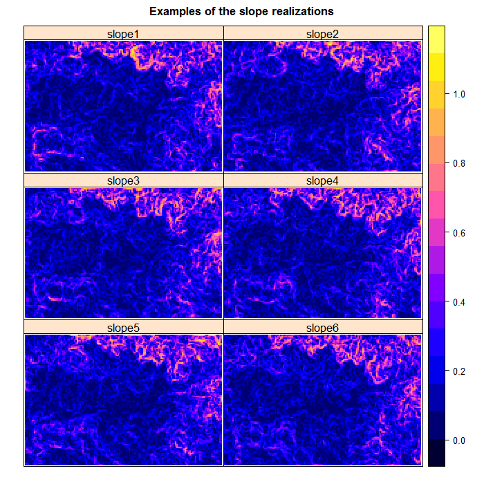

```r
# coerce slopes list to a SpatialGridDataFrame
s <- slope_sample[[1]]
for (i in 2:length(slope_sample)) {
  s@data[i] <- slope_sample[[i]]@data
}
names(s@data) <- paste("slope", c(1:ncol(s)), sep = "")
slope_sample <- s
rm(s)

# view the sample of the model output
spplot(slope_sample[c(5,6,3,4,1,2)], main = list(label = "Examples of the slope realizations", cex = 1))
```

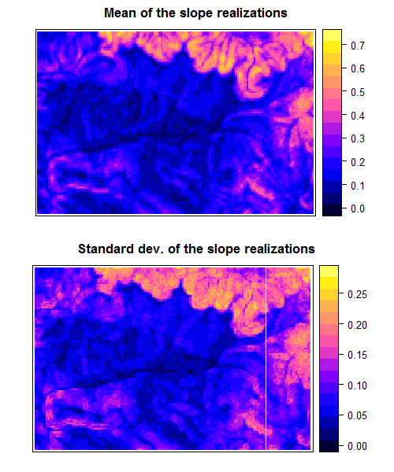

```r
# compute and plot the slope sample statistics
# e.g. mean and standard deviation
slope_mean <- mean(slope_sample)
slope_sd <- sd(slope_sample, na.rm = TRUE) # na.rm = TRUE is necessary, because slope cannot be calculated at the border
m <- spplot(slope_mean, main = list(label = "Mean of the slope realizations", cex = 1))
s <- spplot(slope_sd, main = list(label = "Standard dev. of the slope realizations", cex = 1))
print(m, split = c(1, 1, 1, 2), more = TRUE)
print(s, split = c(1, 2, 1, 2))
```

```r
rm(m, s)
```

```r
# check the histogram of slope at lowest and highest DEM
l <- which(dem30m@data == min(dem30m@data)) # there is no slope calculated for this outer value so we need to fins a different one
l <- which(dem30m@data < 860)
l
```

```
 [1] 100 101 102 106 107 108 250 251 256 257 258 400
```

```r
# lets take location 400 for l.
h <- which(dem30m@data == max(dem30m@data))
h
```

```
[1] 6898
```

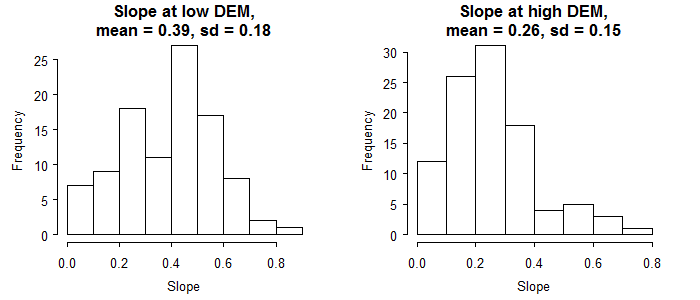

```r
l_mean <- mean(as.numeric(slope_sample@data[400,]))
l_sd <- sd(as.numeric(slope_sample@data[400,]))
h_mean <- mean(as.numeric(slope_sample@data[6898,]))
h_sd <- sd(as.numeric(slope_sample@data[6898,]))

par(mfrow = c(1,2))
hist(as.numeric(slope_sample@data[400,]), main = paste("Slope at low DEM,", "\n",
     "mean = ", round(l_mean, 2), ", sd = ", round(l_sd, 2), sep = ""), xlab = "Slope")
hist(as.numeric(slope_sample@data[6898,]), main = paste("Slope at high DEM,", "\n",
     "mean = ", round(h_mean, 2), ", sd = ", round(h_sd, 2), sep = ""), xlab = "Slope")
```

```r
rm(l, h)
```

We can also look at specific quantites of the slope sample.

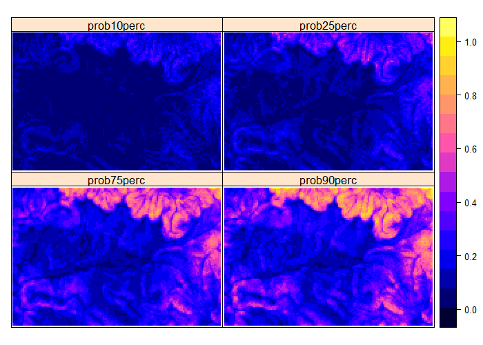

```r
# or quantiles
slope_q <- quantile(slope_sample, probs = c(0.1, 0.25, 0.75, 0.9), na.rm = TRUE)
spplot(slope_q[c(3,4,1,2)], mail = list(label = "Quantiles of slope realizations", cex = 1))
```

For example, find locations with steep slopes that are safe (slope < 0.5) for tourist skiing with probability 90%.

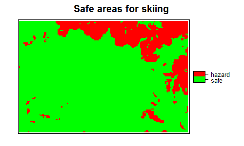

```r
slope_q$safep90 <- factor(ifelse(slope_q$prob90perc > 0.5, 1, 0), labels = c("safe","hazard"))
spplot(slope_q, "safep90", col.regions = c("green","red"), main = "Safe areas for skiing")
```

### Acknowledgements

The Zlatibor dataset was kindly provided by Prof. Branislav Bajat from the University of Belgrade, Serbia.

This project has received funding from the European Union’s Seventh Framework Programme for research, technological development and demonstration under grant agreement no 607000.

### References

Beekhuizen, J. G.B.M. Heuvelink, J. Biesemans and I. Reusen (2011), Effect of DEM uncertainty on the positional accuracy of airborne imagery. IEEE Transactions on Geoscience and Remote Sensing 49, 1567 1577.